# Advanced usage of recurrent neural networks

We will cover the following techniques:

- *Recurrent dropout*, a specific, built-in way to use dropout to fight overfitting in recurrent layers.
- *Stacking recurrent layers*, to increase the representational power of the network (at the cost of higher computational loads).
- *Bidirectional recurrent layers*, which presents the same information to a recurrent network in different ways, increasing accuracy and mitigating forgetting issues.

### 6.3.1 A temperature forecasting problem

Until now, the only sequence data we have covered has been text data, for instance the IMDB dataset and the Reuters dataset. But sequence data is found in many more problems than just language processing. In all of our examples in this section, we will be playing with a weather timeseries dataset recorded at the Weather Station at the Max-Planck-Institute for Biogeochemistry in Jena, Germany: http://www.bgc-jena.mpg.de/wetter/.

In this dataset, fourteen different quantities (such air temperature, atmospheric pressure, humidity, wind direction, etc.) are recorded every ten minutes, over several years. The original data goes back to 2003, but we limit ourselves to data from 2009-2016. This dataset is perfect for learning to work with numerical timeseries. We will use it to build a model that takes as input some data from the recent past (a few days worth of data points) and predicts the air temperature 24 hours in the future.

Download and uncompress the data as follows:

```r
dir.create("~/Downloads/jena_climate", recursive = TRUE)
download.file(
  "https://s3.amazonaws.com/keras-datasets/jena_climate_2009_2016.csv.zip",
  "~/Downloads/jena_climate/jena_climate_2009_2016.csv.zip"
)
unzip(
  "~/Downloads/jena_climate/jena_climate_2009_2016.csv.zip",
  exdir = "~/Downloads/jena_climate"
)
```

#### Listing 6.28 Inspecting the data of the Jena weather dataset

Here is the plot of temperature (in degrees Celsius) over time. On this plot, you can clearly see the yearly periodicity of temperature.

#### Listing 6.29 Plotting the temperature timeseries

`r`r library(ggplot2) ggplot(data, aes(x = 1:nrow(data), y = `T (degC)`)) + geom_line()

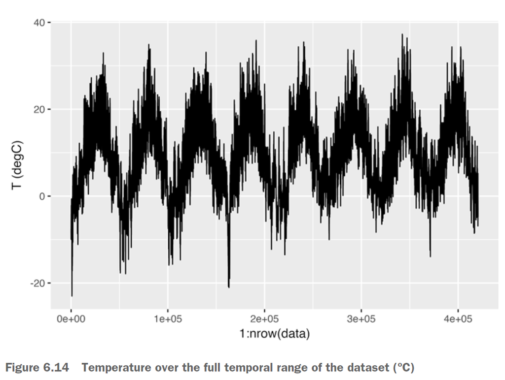

Figure 6.14 Temperature over the full temporal range of the dataset (ºC)

On this plot, you can clearly see the yearly periodicity of temperature.

#### Listing 6.30 Plotting the first 10 days of the temperature timeseries

`r`r ggplot(data[1:1440,], aes(x = 1:1440, y = `T (degC)`)) + geom_line()

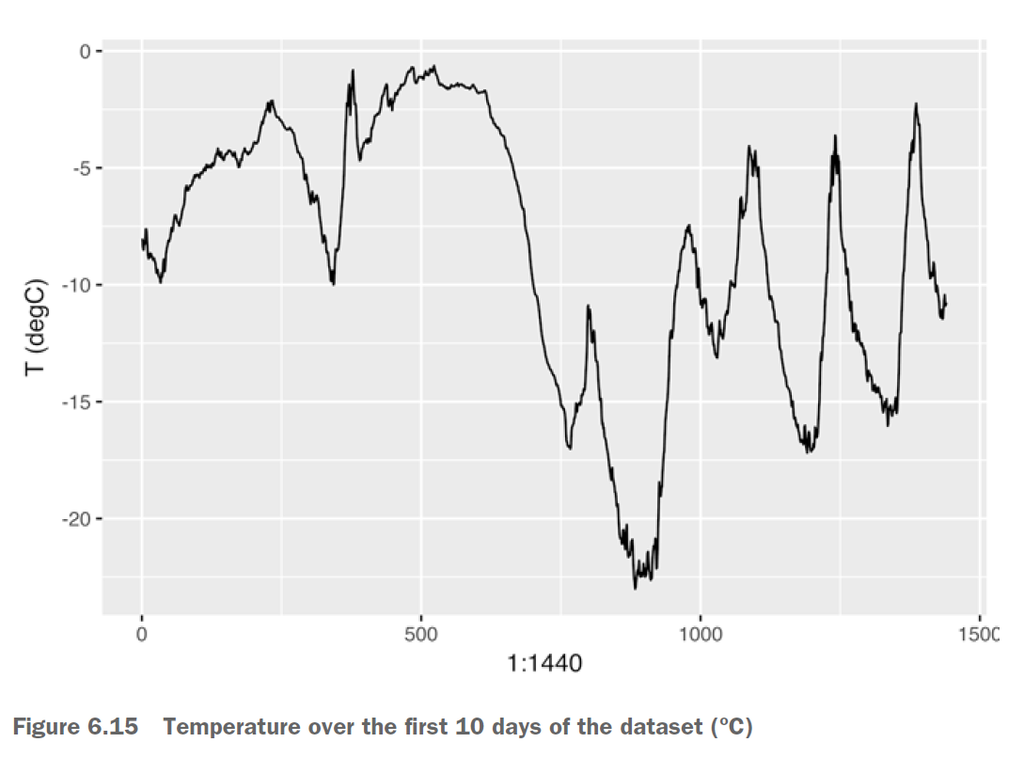

Figure 6.15 Temperature over the first 10 days of the dataset (ºC)

On this plot, you can see daily periodicity, especially evident for the last 4 days. Also note that this 10-day period must be coming from a fairly cold winter month.

데이터는 10분마다 하나씩, 하루는 144개 데이터 포인트

마지막 나흘 정도는 주기가 관찰됨

기온 예측은 월별 평균 기온 예측은 쉽지만 일별 예측은 쉽지 않음

### 6.3.2 Preparing the data

The exact formulation of our problem will be the following: given data going as far back as `lookback` timesteps (a timestep is 10 minutes) and sampled every `steps` timesteps, can we predict the temperature in `delay` timesteps?

We will use the following parameter values:

- `lookback = 1440`, i.e. our observations will go back 10 days.
- `steps = 6`, i.e. our observations will be sampled at one data point per hour.
- `delay = 144`, i.e. our targets will be 24 hours in the future.

To get started, we need to do two things:

- Preprocess the data to a format a neural network can ingest. This is easy: the data is already numerical, so we don’t need to do any vectorization. However each timeseries in the data is on a different scale (e.g. temperature is typically between -20 and +30, but pressure, measured in mbar, is around 1000). So we will normalize each timeseries independently so that they all take small values on a similar scale.
- Write a generator function that takes the current array of float data and yields batches of data from the recent past, along with a target temperature in the future. Because the samples in the dataset are highly redundant (sample *N* and sample *N + 1* will have most of their timesteps in common), it would be wasteful to explicitly allocate every sample. Instead, you’ll generate the samples on the fly using the original data.

First, you’ll convert the R data frame which we read earlier into a matrix of floating point values (we’ll discard the first column which included a text timestamp):

`r`r data <- data.matrix(data[,-1])

You’ll then preprocess the data by subtracting the mean of each timeseries and dividing by the standard deviation. You’re going to use the first 200,000 timesteps as training data, so compute the mean and standard deviation for normalization only on this fraction of the data.

`r`r train_data <- data[1:200000,] mean <- apply(train_data, 2, mean) std <- apply(train_data, 2, sd) data <- scale(data, center = mean, scale = std)

Now here is the data generator you’ll use. It yields a list `(samples, targets)`, where `samples` is one batch of input data and `targets` is the corresponding array of target temperatures. It takes the following arguments:

- `data` – The original array of floating-point data, which you normalized in listing 6.32.
- `lookback` – How many timesteps back the input data should go.
- `delay` – How many timesteps in the future the target should be.
- `min_index` and `max_index` – Indices in the `data` array that delimit which timesteps to draw from. This is useful for keeping a segment of the data for validation and another for testing.
- `shuffle` – Whether to shuffle the samples or draw them in chronological order.
- `batch_size` – The number of samples per batch.
- `step` – The period, in timesteps, at which you sample data. You’ll set it 6 in order to draw one data point every hour.

#### Listing 6.33 Generator yielding timeseries samples and their targets

`r`r generator <- function(data, lookback, delay, min_index, max_index, shuffle = FALSE, batch_size = 128, step = 6) { if (is.null(max_index)) max_index <- nrow(data) - delay - 1 i <- min_index + lookback function() { if (shuffle) { rows <- sample(c((min_index+lookback):max_index), size = batch_size) } else { if (i + batch_size >= max_index) i <<- min_index + lookback rows <- c(i:min(i+batch_size-1, max_index)) i <<- i + length(rows) }

```
samples <- array(0, dim = c(length(rows),
                            lookback / step,
                            dim(data)[[-1]]))
targets <- array(0, dim = c(length(rows)))

for (j in 1:length(rows)) {
  indices <- seq(rows[[j]] - lookback, rows[[j]] - 1,
                 length.out = dim(samples)[[2]])
  samples[j,,] <- data[indices,]
  targets[[j]] <- data[rows[[j]] + delay,2]
}

list(samples, targets)
```

The `i` variable contains the state that tracks next window of data to return, so it is updated using superassignment (e.g. `i <<- i + length(rows)`).

Now, let’s use the abstract `generator` function to instantiate three generators: one for training, one for validation, and one for testing. Each will look at different temporal segments of the original data: the training generator looks at the first 200,000 timesteps, the validation generator looks at the following 100,000, and the test generator looks at the remainder.

`r`r lookback <- 1440 step <- 6 delay <- 144 batch_size <- 128

train_gen <- generator( data, lookback = lookback, delay = delay, min_index = 1, max_index = 200000, shuffle = TRUE, step = step, batch_size = batch_size )

val_gen = generator( data, lookback = lookback, delay = delay, min_index = 200001, max_index = 300000, step = step, batch_size = batch_size )

test_gen <- generator( data, lookback = lookback, delay = delay, min_index = 300001, max_index = NULL, step = step, batch_size = batch_size )

# This is how many steps to draw from `val_gen`

# in order to see the whole validation set:

val_steps <- (300000 - 200001 - lookback) / batch_size

# This is how many steps to draw from `test_gen` # in order to see the whole test set: test_steps <- (nrow(data) - 300001 - lookback) / batch_size

### 6.3.3 A common sense, non-machine learning baseline

Before we start leveraging black-box deep learning models to solve our temperature prediction problem, let’s try out a simple common-sense approach. It will serve as a sanity check, and it will establish a baseline that we will have to beat in order to demonstrate the usefulness of more advanced machine learning models. Such common-sense baselines can be very useful when approaching a new problem for which there is no known solution (yet). A classic example is that of unbalanced classification tasks, where some classes can be much more common than others. If your dataset contains 90% of instances of class A and 10% of instances of class B, then a common sense approach to the classification task would be to always predict “A” when presented with a new sample. Such a classifier would be 90% accurate overall, and any learning-based approach should therefore beat this 90% score in order to demonstrate usefulness. Sometimes such elementary baseline can prove surprisingly hard to beat.

In our case, the temperature timeseries can safely be assumed to be continuous (the temperatures tomorrow are likely to be close to the temperatures today) as well as periodical with a daily period. Thus a common sense approach would be to always predict that the temperature 24 hours from now will be equal to the temperature right now. Let’s evaluate this approach, using the Mean Absolute Error metric (MAE). Mean Absolute Error is simply equal to:

```r
mean(abs(preds - targets))
```

#### Listing 6.35 Computing the common-sense baseline MAE

baseline: 24시간 이후의 기온이 지금과 같을 것이라 가정, MAE로 측정

`r`r evaluate_naive_method <- function() { batch_maes <- c() for (step in 1:val_steps) { c(samples, targets) %<-% val_gen() preds <- samples[,dim(samples)[[2]],2] mae <- mean(abs(preds - targets)) batch_maes <- c(batch_maes, mae) } print(mean(batch_maes)) }

### 6.3.4 A basic machine learning approach

RNN 실행은 비용이 많이 들기 때문에 실행 전에 간단한 모델을 먼저 만들어 보는 것이 좋음

Let’s display the loss curves for validation and training:

`r`r plot(history)

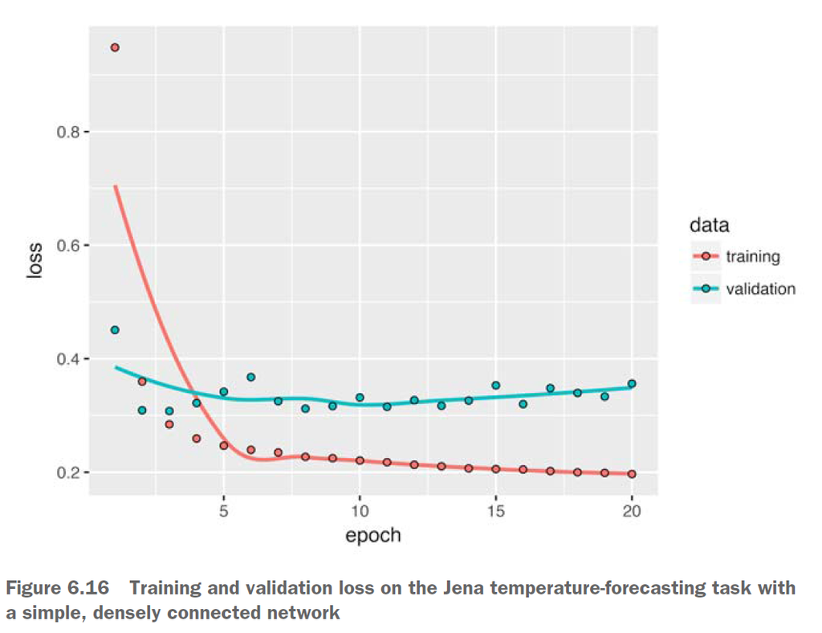

Figure 6.16 Training and validation loss on the Jena temperature-forecasting task with a simple, densely connected network

Some of our validation losses get close to the no-learning baseline, but not very reliably. This goes to show the merit of having had this baseline in the first place: it turns out not to be so easy to outperform. Our common sense contains already a lot of valuable information that a machine learning model does not have access to.

You may ask, if there exists a simple, well-performing model to go from the data to the targets (our common sense baseline), why doesn’t the model we are training find it and improve on it? Simply put: because this simple solution is not what our training setup is looking for. The space of models in which we are searching for a solution, i.e. our hypothesis space, is the space of all possible 2-layer networks with the configuration that we defined. These networks are already fairly complicated. When looking for a solution with a space of complicated models, the simple well-performing baseline might be unlearnable, even if it’s technically part of the hypothesis space. That is a pretty significant limitation of machine learning in general: unless the learning algorithm is hard-coded to look for a specific kind of simple model, parameter learning can sometimes fail to find a simple solution to a simple problem.

## A first recurrent baseline

앞선 모델은 시계열 정보를 잃은 모델임

여기서는 RNN 모델의 또다른 유형인 GRU 레이어를 사용함

GRU는 LSTM과 유사하나 좀 더 단순하고 계산량이 적음

`r`r plot(history)

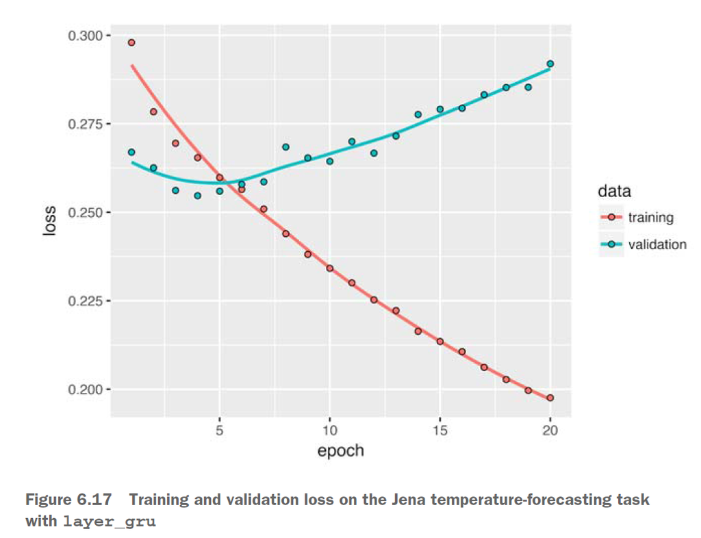

Figure 6.17 Training and validation loss on the Jena temperature-forecasting task with layer_gru

Much better! We are able to significantly beat the common sense baseline, such demonstrating the value of machine learning here, as well as the superiority of recurrent networks compared to sequence-flattening dense networks on this type of task.

Our new validation MAE of ~0.265 (before we start significantly overfitting) translates to a mean absolute error of 2.35˚C after de-normalization. That’s a solid gain on our initial error of 2.57˚C, but we probably still have a bit of margin for improvement.

### 6.3.6 Using recurrent dropout to fight overfitting

드롭 아웃: 우연한 상관 관계를 학습하지 못하도록 입력층의 유닛을 랜덤하게 끔

RNN을 사용할 때는 RNN 레이어에 드롭아웃 옵션을 설정

`r`r plot(history)

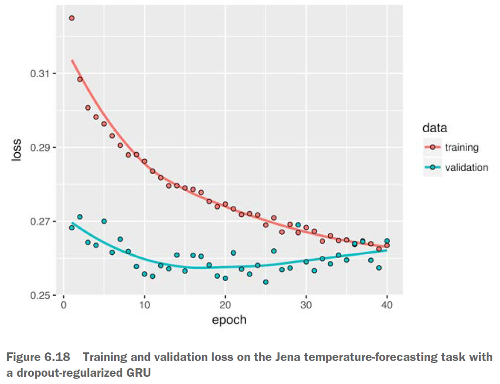

Figure 6.18 Training and validation loss on the Jena temperature-forecasting task with a dropout-regularized GRU

Great success; we are no longer overfitting during the first 20 epochs. However, while we have more stable evaluation scores, our best scores are not much lower than they were previously.

### 6.3.7 Stacking recurrent layers

RNN 레이어를 늘려 네트워크의 표현력을 늘림

RNN을 스택할 때 주의 사항: 마지막 RNN 레이어를 제외하고 나머지 레이어는 `return_sequences = TRUE`로 지정

Let’s take a look at our results:

`r`r plot(history)

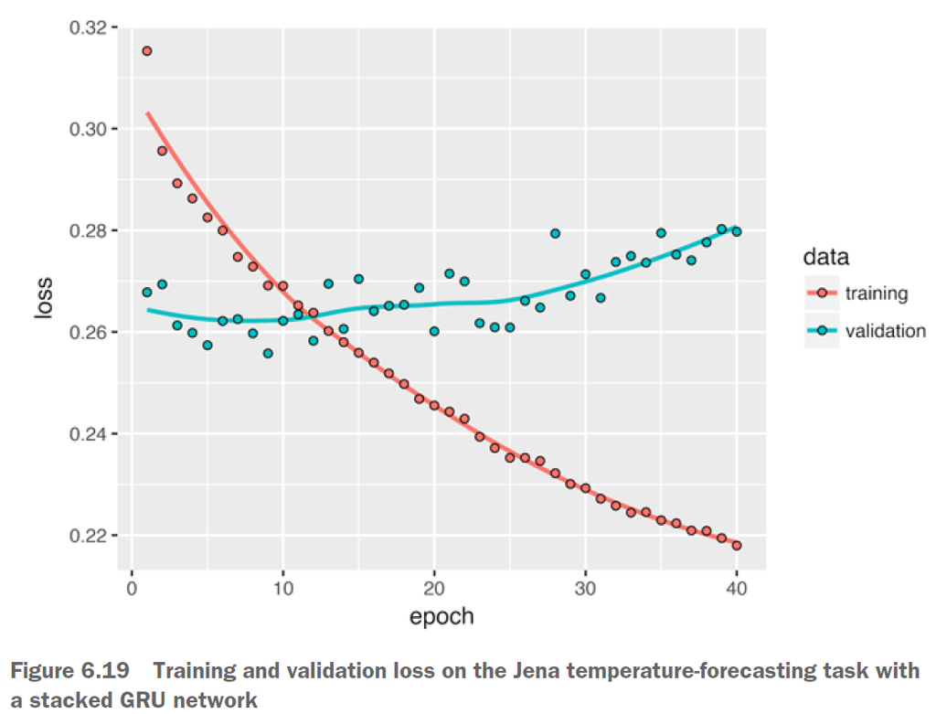

Figure 6.19 Training and validation loss on the Jena temperature-forecasting task with a stacked GRU network

We can see that the added layers does improve ours results by a bit, albeit not very significantly. We can draw two conclusions:

- Since we are still not overfitting too badly, we could safely increase the size of our layers, in quest for a bit of validation loss improvement. This does have a non-negligible computational cost, though.
- Since adding a layer did not help us by a significant factor, we may be seeing diminishing returns to increasing network capacity at this point.

### 6.3.8 Using bidirectional RNNs

bidirectional RNN

- 시간선의 순방향 역방향을 동시에 고려
- 한쪽 방향 RNN이 놓칠 수 있는 패턴을 감지함
- 기온 예측 같이 순방향만 중요한 테스크에는 적합하지 않음
- 자연어 처리에는 자주 선택됨
- 입력 데이터의 방향을 뒤집어서 함께 입력

[figure not shown]

Figure 6.20 Training and validation loss on the Jena temperature-forecasting task with a GRU trained on reversed sequences

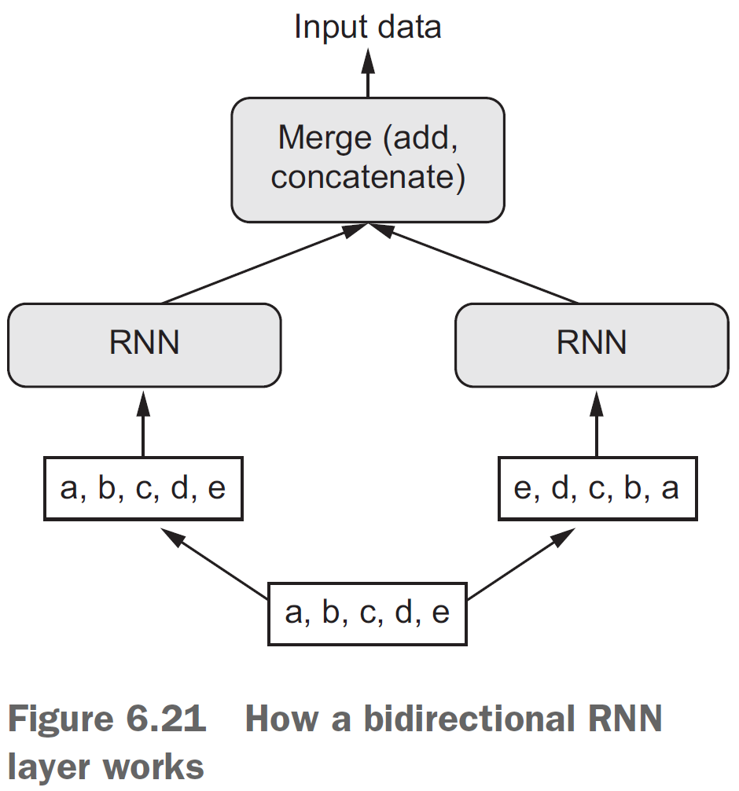

Figure 6.21 How a bidirectional RNN layer works

`r`r reverse_order_generator <- function( data, lookback, delay, min_index, max_index, shuffle = FALSE, batch_size = 128, step = 6) { if (is.null(max_index)) max_index <- nrow(data) - delay - 1 i <- min_index + lookback function() { if (shuffle) { rows <- sample(c((min_index+lookback):max_index), size = batch_size) } else { if (i + batch_size >= max_index) i <<- min_index + lookback rows <- c(i:min(i+batch_size, max_index)) i <<- i + length(rows) }

```
samples <- array(0, dim = c(length(rows),
                            lookback / step,
                            dim(data)[[-1]]))
targets <- array(0, dim = c(length(rows)))

for (j in 1:length(rows)) {
  indices <- seq(rows[[j]] - lookback, rows[[j]],
                 length.out = dim(samples)[[2]])
  samples[j,,] <- data[indices,]
  targets[[j]] <- data[rows[[j]] + delay,2]
}

list(samples[,ncol(samples):1,], targets)
```

train_gen_reverse <- reverse_order_generator( data, lookback = lookback, delay = delay, min_index = 1, max_index = 200000, shuffle = TRUE, step = step, batch_size = batch_size )

val_gen_reverse = reverse_order_generator( data, lookback = lookback, delay = delay, min_index = 200001, max_index = 300000, step = step, batch_size = batch_size )

A bidirectional RNN exploits this idea to improve upon the performance of chronological-order RNNs: it looks at its inputs sequence both ways, obtaining potentially richer representations and capturing patterns that may have been missed by the chronological-order version alone.

케라스에서는 `bidirectional()` 함수를 이용하면 됨

`r`r k_clear_session()

예측 성능은 시간순으로 처리하는 절반의 네트워크에만 영향을 받을 것임

As always, deep learning is more an art than a science. We can provide guidelines that suggest what is likely to work or not work on a given problem, but, ultimately, every problem is unique; you’ll have to evaluate different strategies empirically. There is currently no theory that will tell you in advance precisely what you should do to optimally solve a problem. You must iterate.